# Sampling requirements to detect ecosystem change

# 8 Theoretical results

We then explored how each of these model components affected our ability to detect a change point. We simulate an entire time series, but we also examine the effect of not sampling every year. We specifically study how the amount of samples included and the type of sampling affects the detection probability. In particular, we examine three types of sampling: random, regular, and iterative.

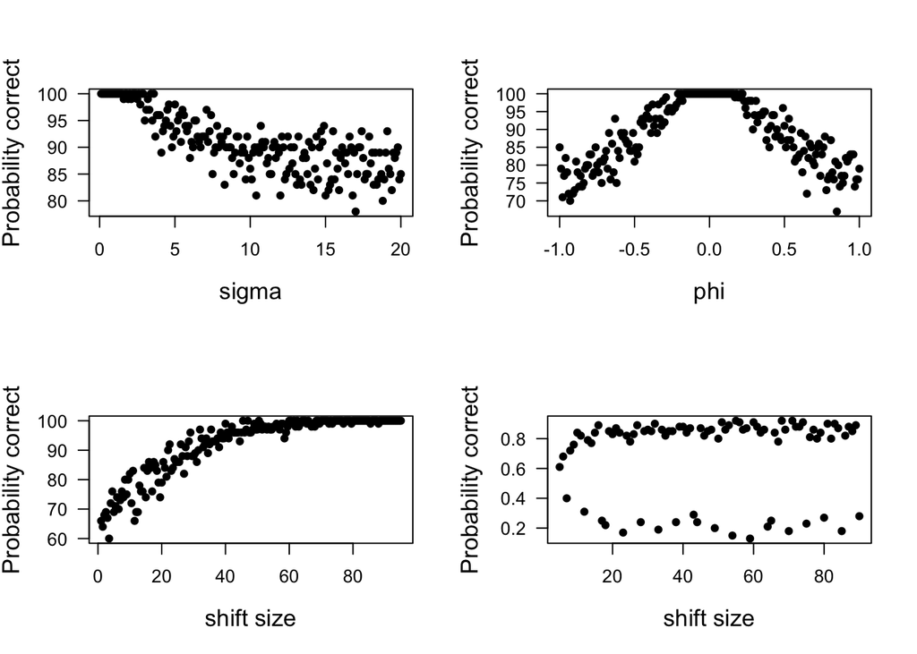

# 9 Limits

Is changepoint necesseraly what we want? We can be interested in changes in mean and/or variance. Right now, I’ve just looked at mean.

A few methods looking at critical transition (e.g., Taranu et al 2018[^4]), or increase variance (e.g., Dakos et al 2012[^5]), etc., will value having more continuous sampling (although the online DLMs method in Taranu et al 2018 allows for non-continuous sampling).

If we know a priori the shape of the relationship, a non-random sampling is preferred, e.g., [VB growth function](https://onlinelibrary.wiley.com/doi/full/10.1002/env.2552) .

[^1]: Anneville, O., Souissi, S., Gammeter, S., Straile, D., 2004. Seasonal and inter-annual scales of variability in phytoplankton assemblages: comparison of phytoplankton dynamics in three peri-alpine lakes over a period of 28 years. Freshwater Biology 49, 98–115. https://doi.org/10.1046/j.1365-2426.2003.01167.x
[^2]: Boucherle, M.M., Züllig, H., 1983. Cladoceran remains as evidence of change in trophic state in three Swiss lakes. Hydrobiologia 103, 141–146. https://doi.org/10.1007/BF00028442
[^3]: Alric, B., Möst, M., Domaizon, I., Pignol, C., Spaak, P., Perga, M.-E., 2016. Local human pressures influence gene flow in a hybridizing Daphnia species complex. J. Evol. Biol. 29, 720–735. https://doi.org/10.1111/jeb.12820
[^4]: Taranu, Z.E., Carpenter, S.R., Frossard, V., Jenny, J.-P., Thomas, Z., Vermaire, J.C., Perga, M.-E., 2018. Can we detect ecosystem critical transitions and signals of changing resilience from paleo-ecological records? Ecosphere 9, e02438. https://doi.org/10.1002/ecs2.2438
[^5]: Dakos, V., Carpenter, S.R., Brock, W.A., Ellison, A.M., Guttal, V., Ives, A.R., Kéfi, S., Livina, V., Seekell, D.A., van Nes, E.H., Scheffer, M., 2012. Methods for Detecting Early Warnings of Critical Transitions in Time Series Illustrated Using Simulated Ecological Data. PloS One 7, e41010. https://doi.org/10.1371/journal.pone.0041010